# Experiment 3 Main Analysis

Josh White

03/01/2022

# Introductory Steps

## Load packages and set seed

```r
library(tidyverse)

# Visualization
library(ggsci)

# Modeling
library(lme4)
library(ordinal) # for clmm function
library(brms) # for Bayesian analyses

# Tables
library(flextable)
library(ftExtra)

theme_set(theme_classic())

set.seed(3838)

# Get logicals for whether Bayesian models have been run
LTFUmods_exist <- fs::file_exists("bayesmods_LTFU.Rdata")
priormods_exist <- fs::file_exists("bayesmods_prior.Rdata")
confmods_exist <- fs::file_exists("bayesmods_conf.Rdata")
combmods_exist <- fs::file_exists("bayesmods_comb.Rdata")
```

## Import and wrangle data

Import data from both timepoints, join together, recode variables etc.

```r
# get subject mapping
subj_map <- read_csv("subjectID-mapping.csv", na = c("", "NA", "na"))

#Get timepoint1 data
da <- read_csv("exp3a-data.csv", na = c("", "NA", "na"))

da <- da %>%
  left_join(subj_map, by = c("subject" = "part1code"))

#WRANGLE 3A

#make factors
da <- da %>%
  mutate(
    gender = factor(gender),
    income = factor(income, levels = c("<20k", "20to40k", "40to60K", "60to80k", "80to100k", ">100k")),
    vignette = factor(vignette, levels = c("G1", "G2", "G5", "G9", "G11",
                                           "L1", "L2", "L5", "L10", "L11"))
  )

#get prior and other variables needed for models
da <- da %>%
  mutate(
    prior = case_when(
      grepl("G", vignette) ~ xprob - yprob,
      grepl("L", vignette) ~ yprob - xprob
    ),
    direction = case_when(
      grepl("G", vignette) ~ "G",
      grepl("L", vignette) ~ "L"
    )
  )

#get whether passed attn_check or not
da <- da %>%
  mutate(
    attn_pass = dummyxprob > 50
  )

#### NOW T2

#Get timepoint2 data
db <- read_csv("exp3b-data.csv", na = c("", "NA", "na"))

#WRANGLE 3B

#make factors
db <- db %>%
  mutate(
    age_t2 = age,
    gender_t2 = factor(gender),
    income_t2 = factor(income, levels = c("<20k", "20to40k", "40to60K", "60to80k", "80to100k", ">100k")),
    education_t2 = education,
    #datetime_t2 = datetime,
    vignette = factor(vignette, levels = c("G1", "G2", "G5", "G9", "G11",
                                           "L1", "L2", "L5", "L10", "L11")),
    trialn_t2 = trialn,
    .keep = "unused"
  )


# get ambiguity aversion
db <- db %>%
  mutate(
    AA = case_when(
      resp_order == "A" ~ -(response - 4),
      resp_order == "B" ~ response - 4,
    )
  )

#get whether passed attn_check or not
db <- db %>%
  mutate(
    attn_pass_t2 = dummyVignetteAnswer > 4
  )

#### COMBINE ###
dc_all <- da %>%
  left_join(db, c("part2code" = "subject", "vignette" = "vignette")) %>%
  rename(part1code = "subject")

dc <- dc_all %>%
  dplyr::select(SubjID, gender:income, vignette, direction, prior, conf, AA, attn_pass, attn_pass_t2, trialn,  trialn_t2)

#passed all timepoints that they did data - for LTFU analysis
dc_pass <- dc %>%
  filter(attn_pass & (attn_pass_t2 | is.na(attn_pass_t2))) %>%
  mutate(
    LTFU = attn_pass & is.na(attn_pass_t2)
  )

dc_both <- dc_pass %>%
  filter(attn_pass & attn_pass_t2)
```

## Demographic statistics

Below I report the demographic statistics for the final sample (who completed and passed both timepoints). To see demographic details for each timepoint, see those analyses.

```r
# get basic descriptives before exclusion
demo_d <- dc_both %>%
  distinct(SubjID, gender, age, education, income)
```

### Gender

```r
demo_d %>%
  count(gender) %>%
  arrange(desc(n)) %>%
  flextable::flextable()
```

| gender | n |
| --- | --- |
| man | 134 |
| woman | 94 |
| other | 1 |
|  | 1 |

### Age

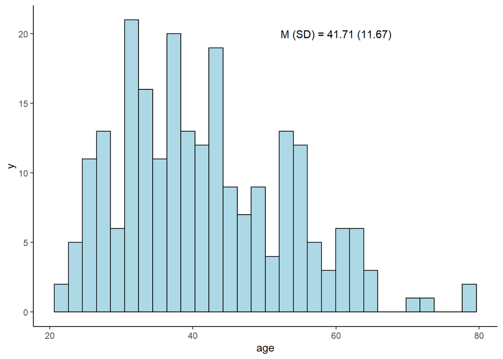

```r
demo_d %>%
  ggplot(aes(x = age)) +
  geom_histogram(fill = "light blue", col = "black") +
  annotate(
    geom = "text", x = 60, y = 20,
    label = paste0("M (SD) = ", round(mean(demo_d$age), 2),
                   " (", round(sd(demo_d$age), 2), ")")
  )
```

### Education (in years)

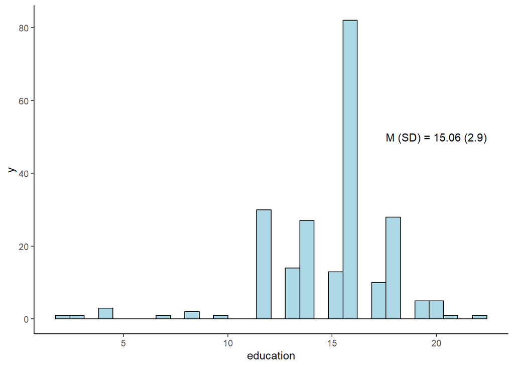

```r
demo_d %>%
  #exclude  participants from demo analysis that somehow responded with text not numbers
  filter(grepl("[0-9]", education)) %>%
  mutate(education = as.numeric(education)) %>%
  ggplot(aes(x = education)) +
  geom_histogram(fill = "light blue", col = "black") +
  annotate(
    geom = "text", x = 20, y = 50,
    label = paste0("M (SD) = ", round(mean(as.numeric(demo_d$education), na.rm = TRUE), 2),
                   " (", round(sd(as.numeric(demo_d$education), na.rm = TRUE), 2), ")")
  )
```

### Income

```r
demo_d %>%
  count(income) %>%
  flextable::flextable()
```

| income | n |
| --- | --- |
| <20k | 33 |
| 20to40k | 56 |
| 40to60K | 46 |
| 60to80k | 44 |
| 80to100k | 24 |
| >100k | 23 |
|  | 4 |

# Analysis

## Within-participants (main) analysis

### Plots

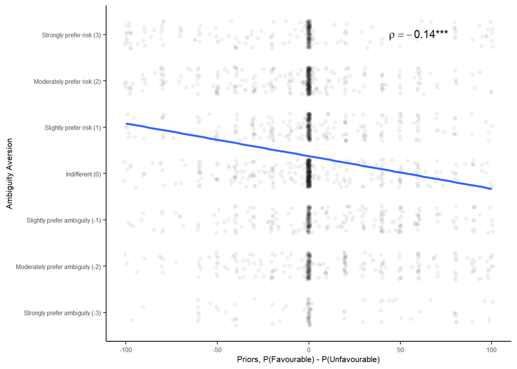

```r
## Priors and Ambiguity Aversion -- alltogether
cors_together <- dc_both %>%
  summarise(
    r = cor(prior, AA, method = "spearman"),
    p = cor.test(prior, AA, method = "spearman")$p.value) %>%
  mutate(
    label = paste0("rho == ", round(r, 2)),
    label = case_when(
      p < .01 ~ paste0("paste(", label, ", '***')"),
      p < .01 ~ paste0("paste(", label, ", '**')"),
      p < .05 ~ paste0("paste(", label, ", '*')"),
      #p < .10 ~ paste0("paste(", label, ", '*')"),
      TRUE ~ label)
  )


together_plot <- dc_both %>%
  ggplot(aes(x = prior, y = AA)) +
  geom_jitter(alpha = 0.05, height = 0.30) +
  geom_smooth(method = "lm", se = FALSE) +
  geom_text(aes(label = label), x = 60, y = 3, col = "black", data = cors_together, fontface = "bold", parse = TRUE) +
  scale_y_continuous(breaks = -3:3, minor_breaks = NULL, limits = (c(-3.30,3.30)),
                     labels = rev(c("Strongly prefer risk (3)", "Moderately prefer risk (2)", "Slightly prefer risk (1)",
                                "Indifferent (0)", "Slightly prefer ambiguity (-1)", "Moderately prefer ambiguity (-2)", "Strongly prefer ambiguity (-3)"))) +
  labs(
    #title = "Regressing ambiguity aversion onto priors collapsing across vignettes"
    x = "Priors, P(Favourable) - P(Unfavourable)",
    y = "Ambiguity Aversion"
  ) +
    theme(legend.position = "none",
        axis.text = element_text(size = 6),
        axis.title = element_text(size = 8))

together_plot
```

```r
## Plot each separately, with correlations too

# get correlations and significance tests for each vignette
cors <- dc_both %>%
  group_by(vignette) %>%
  summarise(
    r = cor(prior, AA, method = "spearman"),
    p = cor.test(prior, AA, method = "spearman")$p.value) %>%
  mutate(
    label = paste0("rho == ", round(r, 2)),
    label = case_when(
      p < .01 ~ paste0("paste(", label, ", '***')"),
      p < .01 ~ paste0("paste(", label, ", '**')"),
      p < .05 ~ paste0("paste(", label, ", '*')"),
      #p < .10 ~ paste0("paste(", label, ", '*')"),
      TRUE ~ label)
  )

#label = if_else(p < .05, paste0("list(", label, ", *)"), label)

# draw plot
vignette_plot <- dc_both %>%
  ggplot(aes(x = prior, y = AA, col = direction)) +
  geom_jitter(alpha = 0.05, height = 0.30, width = 0.10) +
  geom_smooth(method = "lm", se = FALSE) +
  scale_colour_manual(values = c("dodgerblue", "red2")) +
  facet_wrap(~vignette) +
  theme(legend.position = "none") +
  geom_text(aes(label = label), x = 0, y = 2.9, col = "black", data = cors, fontface = "bold", parse = TRUE, size = 3) +
  scale_y_continuous(breaks = -3:3, minor_breaks = NULL, limits = (c(-3.30,3.30))) +
  # scale_y_continuous(breaks = -3:3, minor_breaks = NULL, limits = (c(-3.10,3.10)),
  #                    labels = rev(c("Strongly prefer risk (3)", "Moderately prefer risk (2)", "Slightly prefer risk (1)",
  #                               "Indifferent (0)", "Slightly prefer ambiguity (-1)", "Moderately prefer ambiguity (-2)", "Strongly prefer ambiguity (-3)"))) +
  labs(
    #title = "Regressing ambiguity aversion onto priors within each vignette",
    #caption = "Spearman's correlation coefficient reported due to ordinal nature of AA variable",
    x = "Priors, P(Favourable) - P(Unfavourable)",
    y = "Ambiguity Aversion"
  ) +
    theme(legend.position = "none",
        axis.text = element_text(size = 5.5),
        axis.title = element_text(size = 8))


# return whole correlation table
cors %>%
  dplyr::select(-label) %>%
  mutate(p = round(p,  3)) %>%
  rename(`$\\rho$` = "r") %>%
  flextable::flextable() %>%
  flextable::set_caption("Correlations between Ambiguity Aversion and Prior for each vignette") %>%
  flextable::add_footer_lines("Spearman's correlation coefficient reported due to ordinal nature of AA variable") %>%
  ftExtra::colformat_md(part = "all")
```

Correlations between Ambiguity Aversion and Prior for each vignette

| vignette | ρ | p |
| --- | --- | --- |
| G1 | -0.09463687591 | 0.153 |
| G2 | -0.13888411761 | 0.035 |
| G5 | -0.06539608338 | 0.323 |
| G9 | -0.04571826550 | 0.490 |
| G11 | -0.01210826892 | 0.855 |
| L1 | -0.09282600025 | 0.161 |
| L2 | -0.13435228868 | 0.042 |
| L5 | 0.02579179671 | 0.697 |
| L10 | -0.07399070055 | 0.264 |
| L11 | -0.22891748577 | 0.000 |

Spearman's correlation coefficient reported due to ordinal nature of AA variable

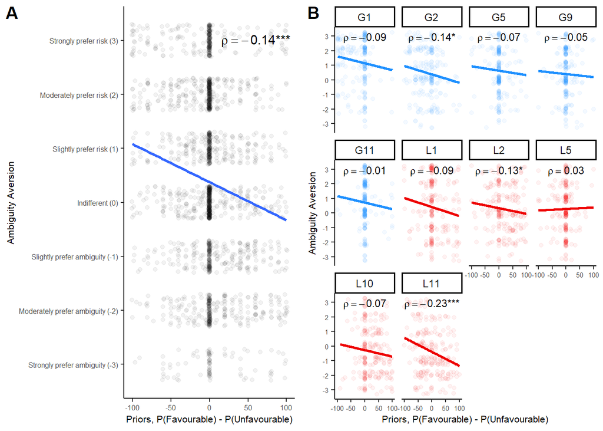

```r
### plot together in 1 panels
cowplot::plot_grid(together_plot, vignette_plot,labels = "AUTO", nrow = 1)
```

```r
ggsave("fig-6.png", width = 7, height = 3.5)
```

### Modeling

Bayesian and Frequentist analyses differ slightly on their preferred model.

#### Bayesian Analysis

##### Prior Models

Fit `prior` models

```r
## prior models
mb0 <- brm(ordered(AA) ~ 1 + (1|SubjID) + (1|vignette), data = dc_both,
           family = cumulative(link = "logit"), cores = 4, seed = 3838)

mb_dir <- brm(ordered(AA) ~ 1 + direction + (1|SubjID) + (1|vignette), data = dc_both,
              family = cumulative(link = "logit"), cores = 4, seed = 3838)

mb_prior  <- brm(ordered(AA) ~ 1 + prior +(1|SubjID) + (1|vignette), data = dc_both,
                 family = cumulative(link = "logit"), cores = 4, seed = 3838)

mb_dir_prior  <- brm(ordered(AA) ~ 1 + direction + prior + (1|SubjID) + (1|vignette), data = dc_both,
                     family = cumulative(link = "logit"), cores = 4, seed = 3838)

mb_int  <- brm(ordered(AA) ~ 1 + direction*prior + (1|SubjID) + (1|vignette), data = dc_both,
               family = cumulative(link = "logit"), cores = 4, seed = 3838)

# Save to file so don't have to reanalyse
save(mb0, mb_dir, mb_prior, mb_dir_prior, mb_int,
     file = "bayesmods_prior.Rdata")
```

```r
# load models, but don't error if they don't exist
try(
 load(file = "bayesmods_prior.Rdata"),
  silent = TRUE
)

# make list of mods
prior_bmods <- list(mb0, mb_dir, mb_prior, mb_dir_prior, mb_int)

tab_bayes_prior <- tibble(
  formula = map_chr(prior_bmods, function(x) as.character(x$formula)[[1]]),
  LOOIC_Estimate = map_dbl(prior_bmods, function(x) loo(x)$looic %>% round(2)),
  LOOIC_SE = map_dbl(prior_bmods, function(x) loo(x)$se_looic %>% round(2))
)

tab_bayes_prior %>%
  flextable::flextable() %>%
  ftExtra::span_header() %>%
  autofit()
```

| formula | LOOIC Estimate | LOOIC SE |
| --- | --- | --- |
| ordered(AA) ~ 1 + (1 \| SubjID) + (1 \| vignette) | 7,655.52 | 77.27 |
| ordered(AA) ~ 1 + direction + (1 \| SubjID) + (1 \| vignette) | 7,654.07 | 77.44 |
| ordered(AA) ~ 1 + prior + (1 \| SubjID) + (1 \| vignette) | 7,631.29 | 77.88 |
| ordered(AA) ~ 1 + direction + prior + (1 \| SubjID) + (1 \| vignette) | 7,628.79 | 77.94 |
| ordered(AA) ~ 1 + direction * prior + (1 \| SubjID) + (1 \| vignette) | 7,628.46 | 78.09 |

**Open here to see full details of LOO statistics (and diagnostic checks for Pareto Smoothed Importance Sampling)**

```r
map(prior_bmods, loo)
```

```
## [[1]]
##
## Computed from 4000 by 2300 log-likelihood matrix
##
##          Estimate   SE
## elpd_loo  -3827.8 38.6
## p_loo       225.5  5.5
## looic      7655.5 77.3
## ------
## Monte Carlo SE of elpd_loo is 0.3.
##
## All Pareto k estimates are good (k < 0.5).
## See help('pareto-k-diagnostic') for details.
##
## [[2]]
##
## Computed from 4000 by 2300 log-likelihood matrix
##
##          Estimate   SE
## elpd_loo  -3827.0 38.7
## p_loo       225.2  5.5
## looic      7654.1 77.4
## ------
## Monte Carlo SE of elpd_loo is 0.2.
##
## All Pareto k estimates are good (k < 0.5).
## See help('pareto-k-diagnostic') for details.
##
## [[3]]
##
## Computed from 4000 by 2300 log-likelihood matrix
##
##          Estimate   SE
## elpd_loo  -3815.6 38.9
## p_loo       227.7  5.6
## looic      7631.3 77.9
## ------
## Monte Carlo SE of elpd_loo is 0.3.
##
## All Pareto k estimates are good (k < 0.5).
```

[output cut: 21 more lines]

```
## See help('pareto-k-diagnostic') for details.
##
## [[5]]
##
## Computed from 4000 by 2300 log-likelihood matrix
##
##          Estimate   SE
## elpd_loo  -3814.2 39.0
## p_loo       227.5  5.6
## looic      7628.5 78.1
## ------
## Monte Carlo SE of elpd_loo is 0.2.
##
## All Pareto k estimates are good (k < 0.5).
## See help('pareto-k-diagnostic') for details.
```

Here are the full details for the models with best fit. First, model with prior and direction WITH interaction. Second, with slightly worse LOOIC, model with independent prior and direction effects. Looking at the models parameters, both have a large role for priors. This model indicates that holding all other effects constant the odds of a responding in with higher Ambiguity Aversion category. This is assumed to be the same odds as we move from each category (-3 , prefer ambiguity to risk ) due to the proportional odds assumption.

```r
#best fitting model (JUST) is direction and prior WITH interaction
mb_int %>%  summary() # interaction model will shows strong prior effect
```

```
##  Family: cumulative
##   Links: mu = logit; disc = identity
## Formula: ordered(AA) ~ 1 + direction * prior + (1 | SubjID) + (1 | vignette)
##    Data: dc_both (Number of observations: 2300)
##   Draws: 4 chains, each with iter = 2000; warmup = 1000; thin = 1;
##          total post-warmup draws = 4000
##
## Group-Level Effects:
## ~SubjID (Number of levels: 230)
##               Estimate Est.Error l-95% CI u-95% CI Rhat Bulk_ESS Tail_ESS
## sd(Intercept)     1.48      0.09     1.31     1.66 1.00     1270     2149
##
## ~vignette (Number of levels: 10)
##               Estimate Est.Error l-95% CI u-95% CI Rhat Bulk_ESS Tail_ESS
## sd(Intercept)     0.50      0.16     0.28     0.89 1.00     1444     2245
##
## Population-Level Effects:
##                  Estimate Est.Error l-95% CI u-95% CI Rhat Bulk_ESS Tail_ESS
## Intercept[1]        -4.50      0.28    -5.06    -3.94 1.00     1641     1833
## Intercept[2]        -2.53      0.26    -3.05    -2.02 1.00     1535     1733
## Intercept[3]        -1.55      0.25    -2.07    -1.04 1.00     1522     1765
## Intercept[4]        -0.29      0.25    -0.79     0.22 1.00     1503     1673
## Intercept[5]         0.66      0.25     0.17     1.18 1.00     1517     1737
## Intercept[6]         2.38      0.26     1.88     2.90 1.00     1649     2012
## directionL          -0.75      0.33    -1.41    -0.11 1.00     1559     1909
## prior               -0.01      0.00    -0.01    -0.00 1.00     6979     3101
## directionL:prior     0.00      0.00    -0.00     0.01 1.00     6391     3078
##
## Family Specific Parameters:
##      Estimate Est.Error l-95% CI u-95% CI Rhat Bulk_ESS Tail_ESS
## disc     1.00      0.00     1.00     1.00   NA       NA       NA
##
## Draws were sampled using sampling(NUTS). For each parameter, Bulk_ESS
## and Tail_ESS are effective sample size measures, and Rhat is the potential
## scale reduction factor on split chains (at convergence, Rhat = 1).
```

```r
mb_dir_prior %>%  summary()
```

```
##  Family: cumulative
##   Links: mu = logit; disc = identity
## Formula: ordered(AA) ~ 1 + direction + prior + (1 | SubjID) + (1 | vignette)
##    Data: dc_both (Number of observations: 2300)
##   Draws: 4 chains, each with iter = 2000; warmup = 1000; thin = 1;
##          total post-warmup draws = 4000
##
## Group-Level Effects:
## ~SubjID (Number of levels: 230)
##               Estimate Est.Error l-95% CI u-95% CI Rhat Bulk_ESS Tail_ESS
## sd(Intercept)     1.48      0.09     1.31     1.67 1.00     1157     1992
##
## ~vignette (Number of levels: 10)
##               Estimate Est.Error l-95% CI u-95% CI Rhat Bulk_ESS Tail_ESS
## sd(Intercept)     0.50      0.18     0.28     0.94 1.00     1379     2115
##
## Population-Level Effects:
##              Estimate Est.Error l-95% CI u-95% CI Rhat Bulk_ESS Tail_ESS
## Intercept[1]    -4.52      0.28    -5.06    -3.97 1.00     1358     1830
## Intercept[2]    -2.55      0.26    -3.07    -2.03 1.00     1307     1927
## Intercept[3]    -1.57      0.25    -2.09    -1.06 1.00     1281     1668
## Intercept[4]    -0.31      0.25    -0.83     0.20 1.00     1282     1784
## Intercept[5]     0.64      0.25     0.13     1.15 1.00     1312     1966
## Intercept[6]     2.36      0.26     1.84     2.89 1.00     1367     2093
## directionL      -0.75      0.34    -1.43    -0.08 1.00     1412     2055
## prior           -0.01      0.00    -0.01    -0.00 1.00     4788     3271
##
## Family Specific Parameters:
##      Estimate Est.Error l-95% CI u-95% CI Rhat Bulk_ESS Tail_ESS
## disc     1.00      0.00     1.00     1.00   NA       NA       NA
##
## Draws were sampled using sampling(NUTS). For each parameter, Bulk_ESS
## and Tail_ESS are effective sample size measures, and Rhat is the potential
## scale reduction factor on split chains (at convergence, Rhat = 1).
```

Plot (fixed effects of) both models to see differences in predictions, though. This also shows extremely similar predictions between these two models.

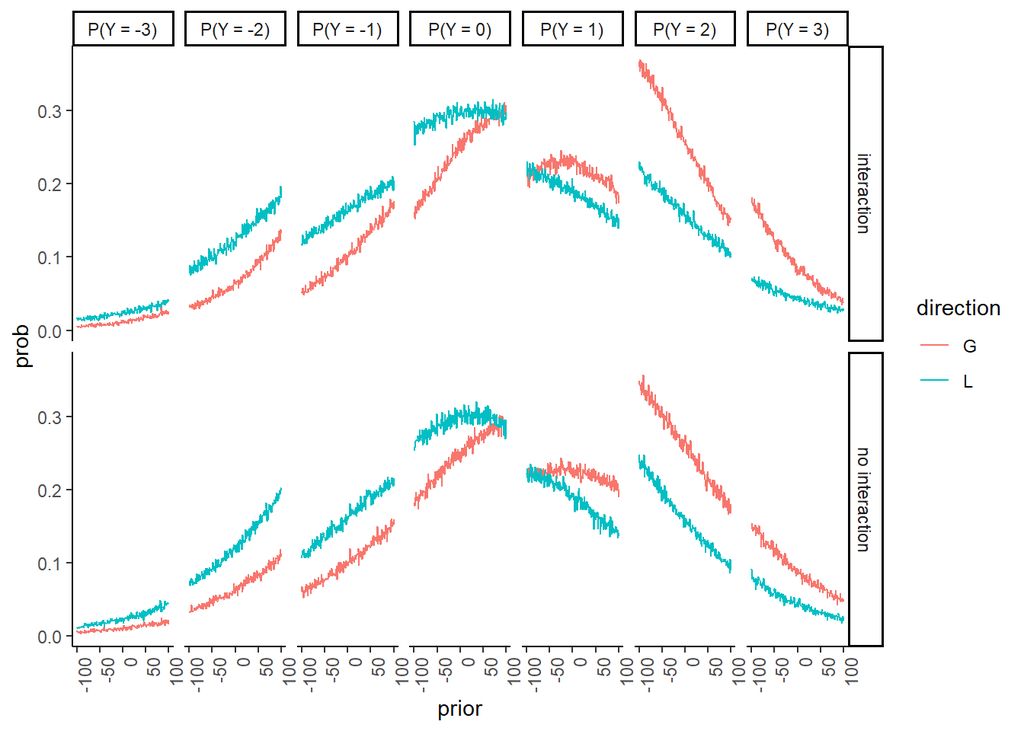

```r
preddat <- expand.grid(prior = -100:100,
            direction = c("G", "L"))

preds_noint <-
  cbind(preddat,
        predict(mb_dir_prior, newdata = preddat, re_formula = NA)
        ) %>%
  pivot_longer(cols = `P(Y = -3)`:`P(Y = 3)`,
               names_to = "level",
               values_to= "prob") %>%
  mutate(model = "no interaction")

preds_int <-
  cbind(preddat,
        predict(mb_int, newdata = preddat, re_formula = NA)
        ) %>%
  pivot_longer(cols = `P(Y = -3)`:`P(Y = 3)`,
               names_to = "level",
               values_to= "prob") %>%
  mutate(model = "interaction")

rbind(preds_noint, preds_int) %>%
  mutate(
    level = factor(level),
    level = fct_relevel(level, c("P(Y = -3)", "P(Y = -2)"))
  ) %>%
  ggplot(aes(x = prior, col = direction, y = prob)) +
  geom_line() +
  facet_grid(model~level) +
  theme(
    axis.text.x = element_text(angle = 90, hjust = 1)
  )
```

##### Confidence Models

Fit `confidence` models

```r
mb_conf  <- brm(ordered(AA) ~ 1 + conf +(1|SubjID) + (1|vignette), data = dc_both,
                family = cumulative(link = "logit"), cores = 4, seed = 3838)
mb_dir_conf  <- brm(ordered(AA) ~ 1 + direction + conf + (1|SubjID) + (1|vignette), data = dc_both,
                    family = cumulative(link = "logit"), cores = 4, seed = 3838)
mb_confint  <- brm(ordered(AA) ~ 1 + direction*conf + (1|SubjID) + (1|vignette), data = dc_both,
                   family = cumulative(link = "logit"), cores = 4, seed = 3838)

# Save to file so don't have to reanalyse
save(mb_conf, mb_dir_conf, mb_confint,
     file = "bayesmods_conf.Rdata")
```

Analysing LOOIC shows that model including `direction` and `confidence` is the best fit of all the ‘confidence models’.

```r
# load models, but don't error if they don't exist
try(
 load(file = "bayesmods_conf.Rdata"),
 silent = TRUE
)

conf_bmods <- list(mb0, mb_dir, mb_conf, mb_dir_conf, mb_confint)

tab_bayes_conf <- tibble(
  formula = map_chr(conf_bmods, function(x) as.character(x$formula)[[1]]),
  LOOIC_Estimate = map_dbl(conf_bmods, function(x) loo(x)$looic) %>%  round(2),
  LOOIC_SE = map_dbl(conf_bmods, function(x) loo(x)$se_looic) %>% round(2)
)

tab_bayes_conf %>%
  flextable::flextable() %>%
  ftExtra::span_header() %>%
  autofit()
```

| formula | LOOIC Estimate | LOOIC SE |
| --- | --- | --- |
| ordered(AA) ~ 1 + (1 \| SubjID) + (1 \| vignette) | 7,655.52 | 77.27 |
| ordered(AA) ~ 1 + direction + (1 \| SubjID) + (1 \| vignette) | 7,654.07 | 77.44 |
| ordered(AA) ~ 1 + conf + (1 \| SubjID) + (1 \| vignette) | 7,654.07 | 77.61 |
| ordered(AA) ~ 1 + direction + conf + (1 \| SubjID) + (1 \| vignette) | 7,652.99 | 77.69 |
| ordered(AA) ~ 1 + direction * conf + (1 \| SubjID) + (1 \| vignette) | 7,653.34 | 77.57 |

**Open here to see full details of LOO statistics (and diagnostic checks for Pareto Smoothed Importance Sampling)**

```r
map(conf_bmods, loo)
```

```
## [[1]]
##
## Computed from 4000 by 2300 log-likelihood matrix
##
##          Estimate   SE
## elpd_loo  -3827.8 38.6
## p_loo       225.5  5.5
## looic      7655.5 77.3
## ------
## Monte Carlo SE of elpd_loo is 0.3.
##
## All Pareto k estimates are good (k < 0.5).
## See help('pareto-k-diagnostic') for details.
##
## [[2]]
##
## Computed from 4000 by 2300 log-likelihood matrix
##
##          Estimate   SE
## elpd_loo  -3827.0 38.7
## p_loo       225.2  5.5
## looic      7654.1 77.4
## ------
## Monte Carlo SE of elpd_loo is 0.2.
##
## All Pareto k estimates are good (k < 0.5).
## See help('pareto-k-diagnostic') for details.
##
## [[3]]
##
## Computed from 4000 by 2300 log-likelihood matrix
##
##          Estimate   SE
## elpd_loo  -3827.0 38.8
## p_loo       225.9  5.5
## looic      7654.1 77.6
## ------
## Monte Carlo SE of elpd_loo is 0.3.
##
## All Pareto k estimates are good (k < 0.5).
```

[output cut: 21 more lines]

```
## See help('pareto-k-diagnostic') for details.
##
## [[5]]
##
## Computed from 4000 by 2300 log-likelihood matrix
##
##          Estimate   SE
## elpd_loo  -3826.7 38.8
## p_loo       226.6  5.6
## looic      7653.3 77.6
## ------
## Monte Carlo SE of elpd_loo is 0.2.
##
## All Pareto k estimates are good (k < 0.5).
## See help('pareto-k-diagnostic') for details.
```

Here are the full details for the models with best fit.

```r
#best fitting model (JUST) is just with confidence (and no direction)
mb_conf %>%  summary()
```

```
##  Family: cumulative
##   Links: mu = logit; disc = identity
## Formula: ordered(AA) ~ 1 + conf + (1 | SubjID) + (1 | vignette)
##    Data: dc_both (Number of observations: 2300)
##   Draws: 4 chains, each with iter = 2000; warmup = 1000; thin = 1;
##          total post-warmup draws = 4000
##
## Group-Level Effects:
## ~SubjID (Number of levels: 230)
##               Estimate Est.Error l-95% CI u-95% CI Rhat Bulk_ESS Tail_ESS
## sd(Intercept)     1.46      0.09     1.29     1.66 1.00     1048     1423
##
## ~vignette (Number of levels: 10)
##               Estimate Est.Error l-95% CI u-95% CI Rhat Bulk_ESS Tail_ESS
## sd(Intercept)     0.69      0.20     0.42     1.17 1.00     1109     1630
##
## Population-Level Effects:
##              Estimate Est.Error l-95% CI u-95% CI Rhat Bulk_ESS Tail_ESS
## Intercept[1]    -3.89      0.29    -4.44    -3.31 1.01      606      780
## Intercept[2]    -1.93      0.27    -2.46    -1.39 1.01      564      855
## Intercept[3]    -0.97      0.27    -1.49    -0.43 1.01      579      847
## Intercept[4]     0.28      0.27    -0.24     0.82 1.01      571      915
## Intercept[5]     1.23      0.27     0.71     1.78 1.01      580      866
## Intercept[6]     2.94      0.28     2.41     3.49 1.01      622      994
## conf             0.09      0.04     0.01     0.17 1.00     2176     2737
##
## Family Specific Parameters:
##      Estimate Est.Error l-95% CI u-95% CI Rhat Bulk_ESS Tail_ESS
## disc     1.00      0.00     1.00     1.00   NA       NA       NA
##
## Draws were sampled using sampling(NUTS). For each parameter, Bulk_ESS
## and Tail_ESS are effective sample size measures, and Rhat is the potential
## scale reduction factor on split chains (at convergence, Rhat = 1).
```

```r
mb_dir_conf %>%  summary()
```

```
##  Family: cumulative
##   Links: mu = logit; disc = identity
## Formula: ordered(AA) ~ 1 + direction + conf + (1 | SubjID) + (1 | vignette)
##    Data: dc_both (Number of observations: 2300)
##   Draws: 4 chains, each with iter = 2000; warmup = 1000; thin = 1;
##          total post-warmup draws = 4000
##
## Group-Level Effects:
## ~SubjID (Number of levels: 230)
##               Estimate Est.Error l-95% CI u-95% CI Rhat Bulk_ESS Tail_ESS
## sd(Intercept)     1.47      0.09     1.30     1.65 1.01      872     1840
##
## ~vignette (Number of levels: 10)
##               Estimate Est.Error l-95% CI u-95% CI Rhat Bulk_ESS Tail_ESS
## sd(Intercept)     0.53      0.17     0.29     0.95 1.00     1209     1906
##
## Population-Level Effects:
##              Estimate Est.Error l-95% CI u-95% CI Rhat Bulk_ESS Tail_ESS
## Intercept[1]    -4.32      0.30    -4.95    -3.75 1.00     1038     1905
## Intercept[2]    -2.36      0.28    -2.95    -1.82 1.00      974     1598
## Intercept[3]    -1.40      0.28    -1.97    -0.85 1.00      961     1565
## Intercept[4]    -0.15      0.28    -0.71     0.39 1.00      931     1585
## Intercept[5]     0.80      0.28     0.25     1.33 1.00      934     1458
## Intercept[6]     2.51      0.29     1.95     3.06 1.00     1051     1624
## directionL      -0.82      0.35    -1.54    -0.17 1.00      902     1663
## conf             0.09      0.04     0.01     0.17 1.00     2232     2561
##
## Family Specific Parameters:
##      Estimate Est.Error l-95% CI u-95% CI Rhat Bulk_ESS Tail_ESS
## disc     1.00      0.00     1.00     1.00   NA       NA       NA
##
## Draws were sampled using sampling(NUTS). For each parameter, Bulk_ESS
## and Tail_ESS are effective sample size measures, and Rhat is the potential
## scale reduction factor on split chains (at convergence, Rhat = 1).
```

```r
mb_confint %>%  summary() # interaction model will shows strong prior effect
```

```
##  Family: cumulative
##   Links: mu = logit; disc = identity
## Formula: ordered(AA) ~ 1 + direction * conf + (1 | SubjID) + (1 | vignette)
##    Data: dc_both (Number of observations: 2300)
##   Draws: 4 chains, each with iter = 2000; warmup = 1000; thin = 1;
##          total post-warmup draws = 4000
##
## Group-Level Effects:
## ~SubjID (Number of levels: 230)
##               Estimate Est.Error l-95% CI u-95% CI Rhat Bulk_ESS Tail_ESS
## sd(Intercept)     1.47      0.09     1.30     1.66 1.00     1153     2108
##
## ~vignette (Number of levels: 10)
##               Estimate Est.Error l-95% CI u-95% CI Rhat Bulk_ESS Tail_ESS
## sd(Intercept)     0.52      0.17     0.29     0.96 1.00     1168     1625
##
## Population-Level Effects:
##                 Estimate Est.Error l-95% CI u-95% CI Rhat Bulk_ESS Tail_ESS
## Intercept[1]       -4.26      0.30    -4.85    -3.68 1.00     1041     1876
## Intercept[2]       -2.30      0.28    -2.86    -1.73 1.00      960     1612
## Intercept[3]       -1.33      0.28    -1.89    -0.77 1.00      953     1910
## Intercept[4]       -0.08      0.28    -0.63     0.48 1.00      953     1697
## Intercept[5]        0.86      0.28     0.31     1.43 1.00      962     1725
## Intercept[6]        2.58      0.29     2.00     3.16 1.00      999     1962
## directionL         -0.69      0.37    -1.44     0.03 1.00      969     1596
## conf                0.12      0.05     0.03     0.22 1.00     2372     2713
## directionL:conf    -0.07      0.06    -0.19     0.05 1.00     3842     3371
##
## Family Specific Parameters:
##      Estimate Est.Error l-95% CI u-95% CI Rhat Bulk_ESS Tail_ESS
## disc     1.00      0.00     1.00     1.00   NA       NA       NA
##
## Draws were sampled using sampling(NUTS). For each parameter, Bulk_ESS
## and Tail_ESS are effective sample size measures, and Rhat is the potential
## scale reduction factor on split chains (at convergence, Rhat = 1).
```

##### Combined model

Fit `combined` model combining best `prior` and `confidence` models

```r
## COMBINE FOR BEST FITTING MODEL?
mb_combined <- brm(ordered(AA) ~ 1 + direction*prior + conf + (1|SubjID) + (1|vignette), data = dc_both,
                   family = cumulative(link = "logit"), cores = 4, seed = 3838)
mb_combined_noint <- brm(ordered(AA) ~ 1 + direction + prior + conf + (1|SubjID) + (1|vignette), data = dc_both,
                   family = cumulative(link = "logit"), cores = 4, seed = 3838)

# Save to file so don't have to reanalyse
save(mb_combined, mb_combined_noint, file = "bayesmods_comb.Rdata")
```

LOOIC shows that combined model is preferred to the best ‘prior model’. Even though it wasn’t pre-registered, I also analysed whether a combined model without any interactions would fit any better.

```r
# load models, but don't error if they don't exist
try(
 load(file = "bayesmods_comb.Rdata"),
 silent = TRUE
)

comb_bmods <- list(mb_int, mb_combined,  mb_combined_noint)

tab_bayes_comb <- tibble(
  formula = map_chr(comb_bmods, function(x) as.character(x$formula)[[1]]),
  LOOIC_Estimate = map_dbl(comb_bmods, function(x) loo(x)$looic) %>%  round(2),
  LOOIC_SE = map_dbl(comb_bmods, function(x) loo(x)$se_looic) %>%  round(2)
)

tab_bayes_comb %>%
  flextable::flextable() %>%
  ftExtra::span_header() %>%
  autofit()
```

| formula | LOOIC Estimate | LOOIC SE |
| --- | --- | --- |
| ordered(AA) ~ 1 + direction * prior + (1 \| SubjID) + (1 \| vignette) | 7,628.46 | 78.09 |
| ordered(AA) ~ 1 + direction * prior + conf + (1 \| SubjID) + (1 \| vignette) | 7,627.33 | 78.45 |
| ordered(AA) ~ 1 + direction + prior + conf + (1 \| SubjID) + (1 \| vignette) | 7,626.60 | 78.19 |

**Open here to see full details of LOO statistics (and diagnostic checks for Pareto Smoothed Importance Sampling)**

```r
map(comb_bmods, loo)
```

```
## [[1]]
##
## Computed from 4000 by 2300 log-likelihood matrix
##
##          Estimate   SE
## elpd_loo  -3814.2 39.0
## p_loo       227.5  5.6
## looic      7628.5 78.1
## ------
## Monte Carlo SE of elpd_loo is 0.2.
##
## All Pareto k estimates are good (k < 0.5).
## See help('pareto-k-diagnostic') for details.
##
## [[2]]
##
## Computed from 4000 by 2300 log-likelihood matrix
##
##          Estimate   SE
## elpd_loo  -3813.7 39.2
## p_loo       228.5  5.7
## looic      7627.3 78.4
## ------
## Monte Carlo SE of elpd_loo is 0.2.
##
## Pareto k diagnostic values:
##                          Count Pct.    Min. n_eff
## (-Inf, 0.5]   (good)     2299  100.0%  1500
##  (0.5, 0.7]   (ok)          1    0.0%  5537
##    (0.7, 1]   (bad)         0    0.0%  <NA>
##    (1, Inf)   (very bad)    0    0.0%  <NA>
##
## All Pareto k estimates are ok (k < 0.7).
## See help('pareto-k-diagnostic') for details.
##
## [[3]]
##
## Computed from 4000 by 2300 log-likelihood matrix
##
##          Estimate   SE
## elpd_loo  -3813.3 39.1
## p_loo       225.9  5.5
## looic      7626.6 78.2
## ------
## Monte Carlo SE of elpd_loo is 0.2.
##
## All Pareto k estimates are good (k < 0.5).
## See help('pareto-k-diagnostic') for details.
```